# Tangency portfolio and Black-Litterman approach

2023-11-23

# 3. Introduction

## 3.1 Packages

We use the following libraries:

1. tidyverse: This package is a powerful toolbox that combines various R packages to streamline data manipulation, visualization, and analysis. It includes versatile tools like ggplot2 for visuals, dplyr for data tweaks, and tidyr for tidying data.
2. quantmod: quantmod specializes in quantitative financial modeling and data analysis. It equips us with tools to handle financial data, perform technical analysis, and model financial time series.
3. DataExplorer: DataExplorer aids in the initial data exploration phase. It provides quick insights through functions for generating summary statistics, visualizing missing data, and plotting variable distributions.
4. corrplot: This package is your go-to for visualizing correlation matrices. It offers functions to create informative correlation plots, helping you grasp relationships between data variables.
5. scales: scales complements R graphics, especially in conjunction with ggplot2. It furnishes various scales and formatting functions to customize plot aesthetics, including axes, labels, and color scales

```r
library(tidyverse)
library(quantmod)
```

```r
library(DataExplorer)
library(corrplot)
library(scales)
```

## 3.2 Investment universe

We have carefully chosen a set of five trackers (ETFs) to represent our univestment universe. An ETF can be defined as a financial product that is based on a basket of different assets, to replicate the actual performance of each selected investment. An ETF has more or less the same proportion of the underlying components of the basket, depending on the style of management of the asset manager.

Our selection strategy is based on several fundamental considerations:

- Investment universe: The investment universe aims at representing different asset classes in order to construct a multi-asset portfolio.
- Diversification strategy: Our commitment to constructing a well-rounded portfolio has been affirmed through diversification across various sectors and industries. Such diversification is a critical risk management tool, curbing overexposure to a single sector or asset class.
- Historical data availability: The selected trackers benefit from a rich repository of historical data and extensive research. The accessibility of such data enable these ETFs to rigorous portfolio management analysis and comprehensive research.

## 3.3 Data cleaning

We initiate data cleaning, a crucial step in data analysis:

- Extracting Adjusted Closing Prices: We use the lapply function to obtain adjusted closing prices, commonly used for return calculations, for a list of stock tickers. This code iterates through each ticker and fetches the adjusted closing prices.
- Combining Stock Returns: To consolidate the adjusted closing prices, we employ cbind, creating a data frame where each column represents a specific stock’s adjusted closing prices.
- Renaming Columns: We label the columns with their corresponding stock tickers, facilitating easy identification.
- Handling Missing Data: We remove rows with missing values from the dataset for quality and consistency.

We initiate data cleaning, a crucial step in data analysis:

- **Extracting adjusted closing prices:** We use the lapply function to obtain adjusted closing prices, commonly used for return calculations, for a list of stock tickers. This code iterates through each ticker and fetches the adjusted closing prices.
- **Combining stock returns:** To consolidate the adjusted closing prices, we employ cbind, creating a data frame where each column represents a specific stock’s adjusted closing prices.
- **Renaming columns:** We label the columns with their corresponding stock tickers, facilitating easy identification.
- **Handling missing data:** We remove rows with missing values from the dataset for quality and consistency.

Arithmetic returns are used for performance assessment, offering a clear view of gains and losses, suitable for short-term analysis, and ensuring transparency.

In order to ensure that the data is properly imported, with non missing values and proper data cleaning procedure, we can implement this line of code in order to learn more about data.

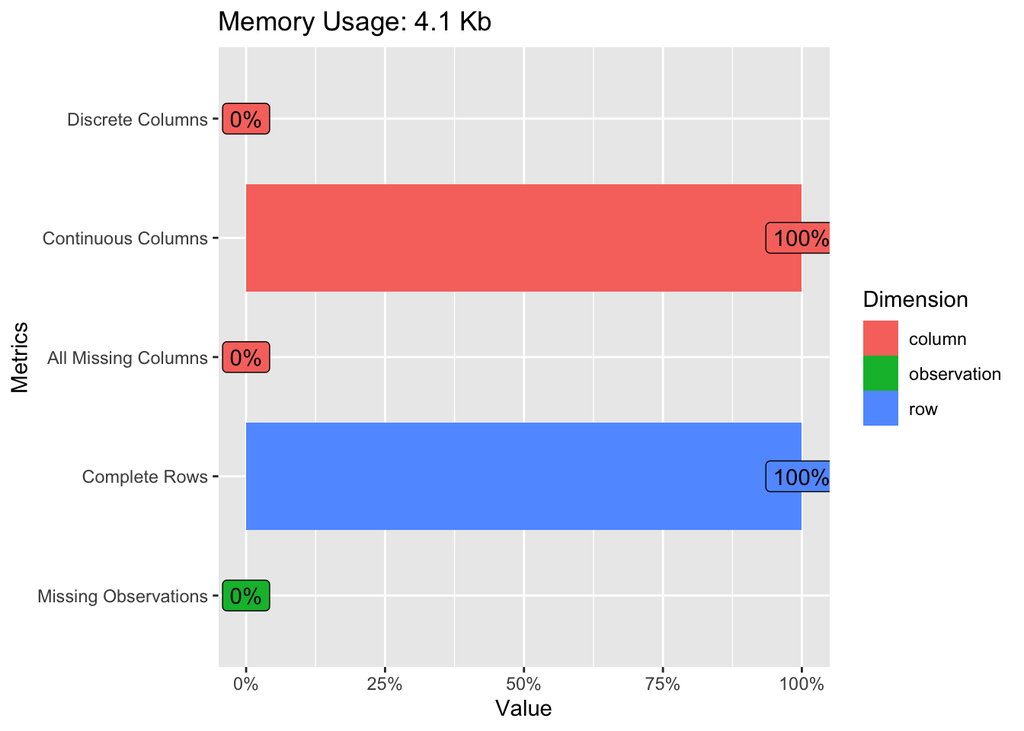

The outperformance of equity returns during the period from 2019 to 2023 can be attributed to several key factors, with a strong emphasis on the role of equity markets, particularly the US market, as the main driver of these returns. Here’s a justification for this phenomenon:

- Global economic growth: The period from 2019 to 2023 witnessed relatively strong global economic growth, with major economies recovering from the aftermath of the 2008 financial crisis. This growth provided a favorable backdrop for equity markets, as rising economic activity often correlates with higher corporate earnings.
- Monetary policy support: Central banks, including the Federal Reserve in the United States, implemented accommodative monetary policies. Low-interest rates and quantitative easing measures aimed to stimulate economic activity and encourage investment in riskier assets like equities.
- US equity dominance: The US equity market, represented by indices like the S&P 500, played a central role in driving global equity returns. The US market is home to a diverse range of sectors, including technology, healthcare, and consumer goods, which collectively contributed to robust earnings growth.
- Technological advancements: The tech sector, dominated by US companies, experienced significant advancements during this period. Innovations in areas such as cloud computing, e-commerce, and digital services led to substantial revenue growth for many tech firms, lifting their stock prices.
- Investor sentiment: Favorable investor sentiment, driven by expectations of continued economic expansion and corporate profits, played a crucial role. Positive sentiment often leads to increased capital flows into equities.
- Sectoral performance: Certain sectors, like technology and healthcare, significantly outperformed others due to their resilience and growth prospects. The performance of these sectors, coupled with their weight in major indices, contributed to overall equity outperformance.
- Globalization: Equity markets became more interconnected than ever, enabling investors to diversify globally. The interplay of global economic factors and cross-border investments amplified returns.
- Risk appetite: As economic conditions improved, investors exhibited a greater appetite for risk, favoring equities over traditional safe-haven assets like bonds.

In summary, the out performance of equity returns during the 2019-2023 period can be largely attributed to a combination of global economic growth, accommodating monetary policies, technological advancements, and the dominant role of the US equity market. The US market’s influence, driven by the performance of its key sectors and companies, has been a primary driver of these strong returns.

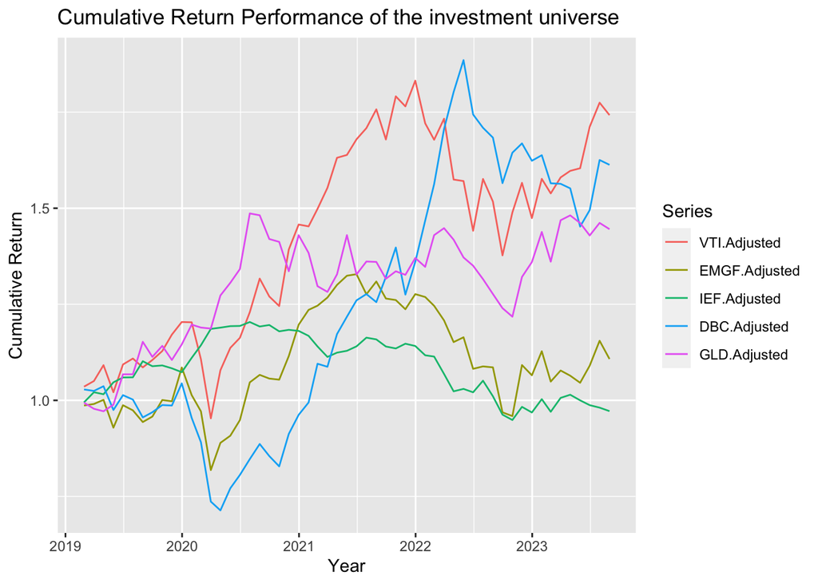

```r
# Calculate Cumulative Returns
cumulative_returns <- cumprod(1 + arith_fin_returns)

# Plot Cumulative Return Performance
library(ggplot2)
autoplot(cumulative_returns, facets = NULL) +
  ggtitle("Cumulative Return Performance of the investment universe") +
  ylab("Cumulative Return") +
  xlab("Year")
```

```r
# Statistical summary of returns for each asset class

summary(arith_fin_returns)
```

```
##      Index             VTI.Adjusted      EMGF.Adjusted
##  Min.   :2019-02-28   Min.   :-0.13886   Min.   :-0.157262
##  1st Qu.:2020-04-15   1st Qu.:-0.02016   1st Qu.:-0.021687
##  Median :2021-05-31   Median : 0.02106   Median : 0.003042
##  Mean   :2021-05-31   Mean   : 0.01161   Mean   : 0.003186
##  3rd Qu.:2022-07-15   3rd Qu.: 0.04301   3rd Qu.: 0.029624
##  Max.   :2023-08-31   Max.   : 0.13133   Max.   : 0.138538
##   IEF.Adjusted         DBC.Adjusted       GLD.Adjusted
##  Min.   :-0.0473497   Min.   :-0.17340   Min.   :-0.071477
##  1st Qu.:-0.0122070   1st Qu.:-0.02351   1st Qu.:-0.021458
##  Median :-0.0030412   Median : 0.01416   Median :-0.003236
##  Mean   :-0.0002956   Mean   : 0.01031   Mean   : 0.007571
##  3rd Qu.: 0.0101189   3rd Qu.: 0.05166   3rd Qu.: 0.031149
##  Max.   : 0.0395168   Max.   : 0.10198   Max.   : 0.107905
```

In portfolio management, statistical analysis plays a key role in understanding financial data patterns. Two essential tools are density plots, which visualize data distributions, and QQ plots, used to assess data conformity to theoretical distributions. These methods assist portfolio managers in making data-driven investment decisions, enhancing the exploration of financial data, and understanding the behavior of selected equities’ returns. As seen from the QQ plot, the results are not normally distributed.

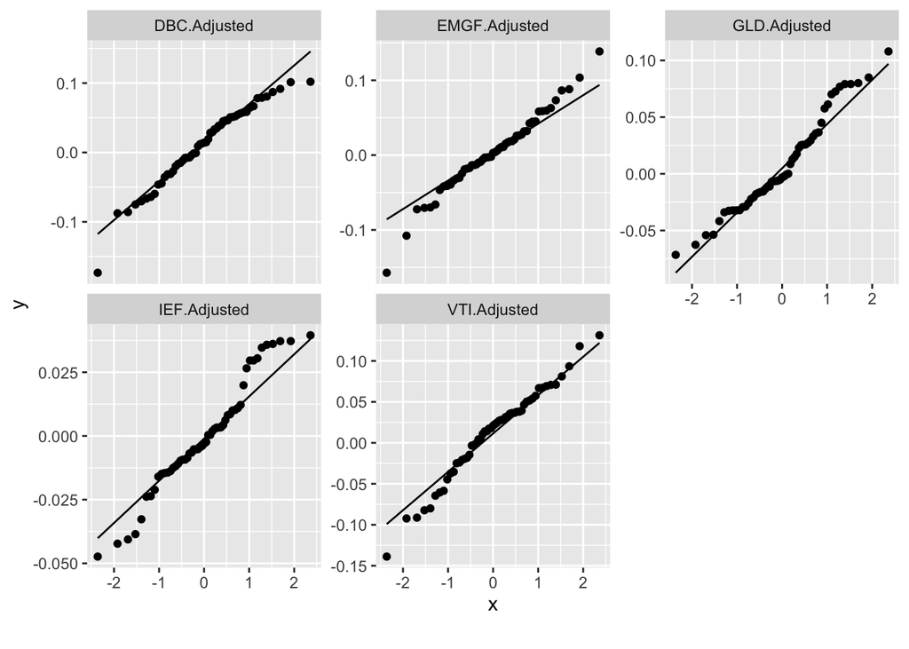

```r
# Advanced statistical analysis for the dataset

#plot_density(arith_fin_returns)
plot_qq(arith_fin_returns)
```

Correlation is a fundamental concept related to diversification, which seeks to use poorly correlated and non correlated assets to construct a portfolio. Diversification aims to boost returns while minimizing risk by investing in assets that respond differently to various events. Prudent investors seeking risk mitigation will diversify their portfolios.

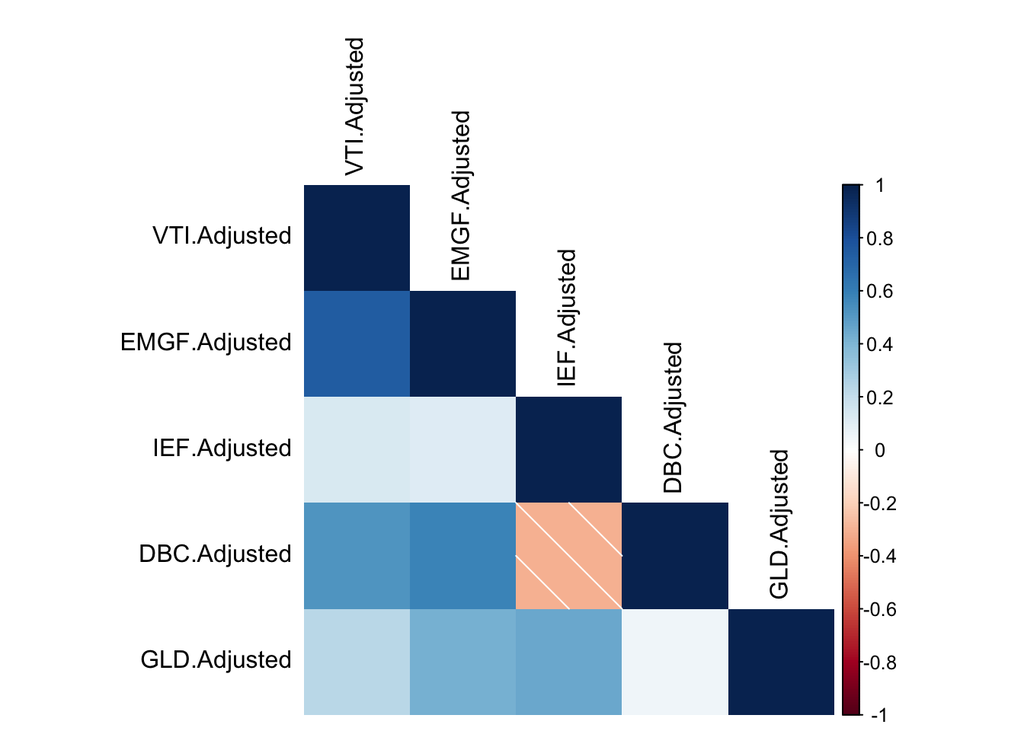

```r
# Correlation analysis

library(corrplot)
corrplot( cor(arith_fin_returns), type='lower', method = "shade", tl.col = 'black', cl.pos = "r", tl.cex = 1)
```

# 4. Modelling of the portfolio

## 4.1 Implementing the Tangency portfolio (TP)

In time series data analysis, a crucial application involves splitting the dataset into training and testing sets based on temporal order. This is vital when working with data that evolves over time, such as stock prices or weather observations.

The training set consists of historical data, while the testing set contains more recent observations. This division allows analysts to assess predictive models and forecasting techniques. By training the model on historical data and evaluating it with recent data, we can determine its ability to make accurate predictions. This is especially important in finance for understanding and forecasting trends over time.

The training set consists of historical data, while the testing set contains more recent observations. This division allows analysts to assess predictive models and forecasting techniques. By training the model on historical data and evaluating it with recent data, we can determine its ability to make accurate predictions. This is especially important in finance for understanding and forecasting trends over time.

For modeling purposes, we’ll create two sub-samples with defined parameters.

1. The first sub-sample will cover the first 20 trading month covered in the data set.

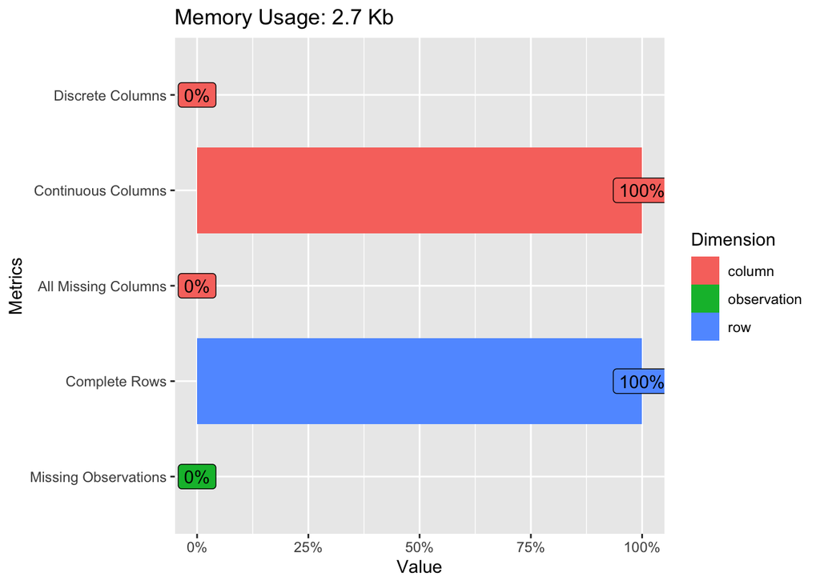

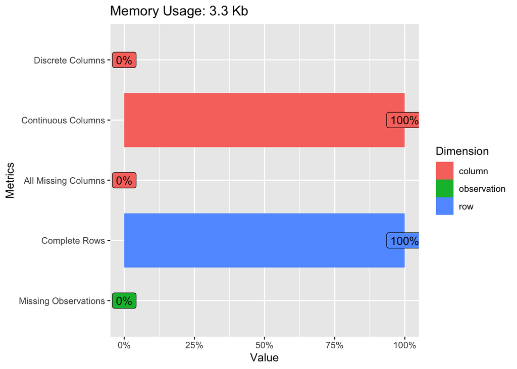

We implement the parameters of the model in order to compute the Tangency Portfolio:

The portfolio allocation consists of both long positions, where investors expect favorable returns, and short positions, where they anticipate weaker performance. Here’s a more detailed explanation of each asset class allocation:

Short Positions: The short segment of the portfolio is allocated to assets where weak performance is expected.

In summary, the portfolio is strategically balanced between long positions, where investors have confidence in the assets’ growth potential, and short positions, where they are expecting weaker performance. The specific allocations provide insights into the level of conviction and sentiment regarding each asset class.

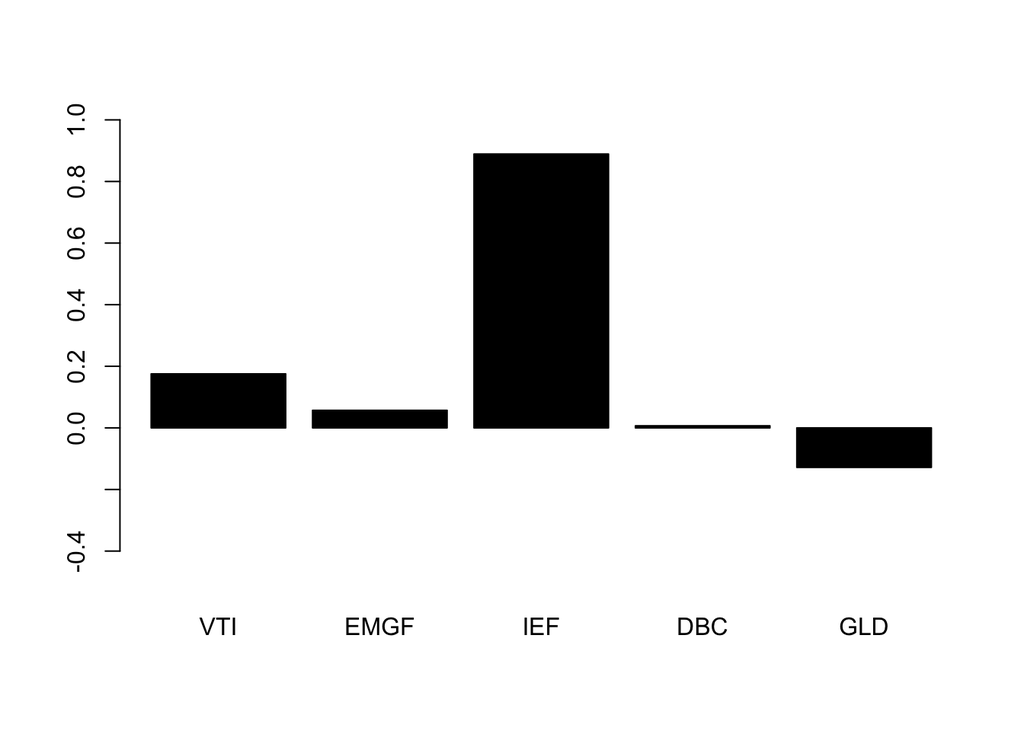

## 4.2 Implementing Black-Litterman approach

This investment universe is designed to provide diversified exposure across a range of asset classes, including broad market indices, emerging market equities, government bonds, commodities, and precious metals. This selection is intended to balance risk and return while capturing growth opportunities and providing a hedge against inflation.

- VTI (Vanguard Total Stock Market ETF): Broad exposure to the global stock market.
- EMGF (iShares MSCI Emerging Markets Multifactor ETF): Exposure to emerging markets with favorable exposure to value, quality, momentum, and size factors.
- IEF (iShares 7-10 Year Treasury Bond ETF): Exposure to intermediate-term government bonds.
- DBC (Invesco DB Commodity Index Tracking Fund): Exposure to a basket of commodities.
- GLD (SPDR Gold Trust): Exposure to gold.

### **2.2.2 Economic data:**

To connect our investment universe selection to the asset allocation, we can refer to market outlooks from the prominent Wall Street most reliable market commentaries. We take the economic data from Goldman Sachs Asset Management, BlackRock, and JPMorgan Asset Management:

**BlackRock Market Outlook 2023:**

- Global GDP growth: +3.1%
- US GDP growth: +2.3%
- Eurozone GDP growth: +2.1%
- China GDP growth: +5.3% S&P 500 earnings: +10%
- US 10-year Treasury yield: 3.3%

**Goldman Sachs Asset Management Market Outlook 2023:**

- Global GDP growth: +2.8%
- US GDP growth: +1.8%
- Eurozone GDP growth: +0.6%
- China GDP growth: +5.0%
- S&P 500 earnings: +6%
- US 10-year Treasury yield: 3.5%

**JPMorgan Asset Management Mid-Year Investment Outlook 2023:**

- Global GDP growth: +3.2%
- US GDP growth: +2.0%
- Eurozone GDP growth: +2.0%
- China GDP growth: +5.2%
- S&P 500 earnings: +8%
- US 10-year Treasury yield: 3.0%

The three financial institutions anticipate +3.0% GDP growth globally, +2.0% GDP growth in the US, and +8% earnings growth for the S&P 500 in 2023. They also predict that the rate on the US 10-year Treasury will hit 3.3%.

Goldman Sachs Asset Management is the most overweight of the three organizations when it comes to asset allocation, with an excess of equities. In terms of bonds, they are likewise underweight, with JPMorgan Asset Management being the most so.

Despite the anticipated slowdown in economic growth, the market outlooks from these three financial institutions generally imply that stocks will remain the favored asset class in 2023. To lower risk, investors can think about diversifying their holdings by including assets like bonds and commodities.

This investment universe is a good option for investors who are looking for a diversified portfolio that offers the potential for both growth and income. The assets in this universe are supported by economic data, market outlook, and investment considerations.

Our matrix view is structured as follows:

```r
Q <- numeric(5)
Q[1] <- 0.00 # neutral view for US equity index (SPY)
Q[2] <- -0.2 # negative view for Global bond index (BNDX)
Q[3] <- 0.00 # neutral view for global equity index (VTI)
Q[4] <- 0.03 # positive view for commodity index (DBC)
Q[5] <- 0.05 # postive view for the gold index (GLD)
tau <- 0.95
```

The Black-Litterman optimization approach is a widely-used method for improving the estimation of expected returns and making asset allocation decisions. It addresses the limitations of traditional mean-variance optimization by incorporating investor views and market equilibrium considerations. The following key steps are performed:

Mixed estimation of returns: The code starts by computing expected returns using mixed estimation. This means combining the market equilibrium-based returns (mu) with the views-based returns (Q) using a blending process. The parameter tau adjusts the strength of the blending. This approach allows investors to incorporate their subjective views on assets into the asset allocation process while considering the overall market dynamics.

Tactical allocation with views directly: This part of the code calculates the tactical asset allocation weights based on views directly. It uses a matrix A_Q and the matrix of uncertainty in views (omega_Q) to determine the optimal portfolio weights. These weights reflect the investor’s views on specific assets and are adjusted according to their confidence in those views.

Tactical allocation with mixed estimation: Similarly, this part calculates tactical asset allocation weights, but this time, it uses the mixed estimation approach. It calculates A_mixed and omega_mixed based on the mixed estimation of expected returns. This allows investors to take a balanced approach, combining both market equilibrium considerations and their own views in the asset allocation process.

Black-Litterman offers a flexible framework for investors to incorporate their insights and views while maintaining a connection to market equilibrium. It’s a valuable tool for optimizing portfolio allocation decisions, especially when investors have specific expectations or insights about the market.

Source [1] Black, F., & Litterman, R. B. (1992). Global portfolio optimization. Financial Analysts Journal, 48(5), 28-43.

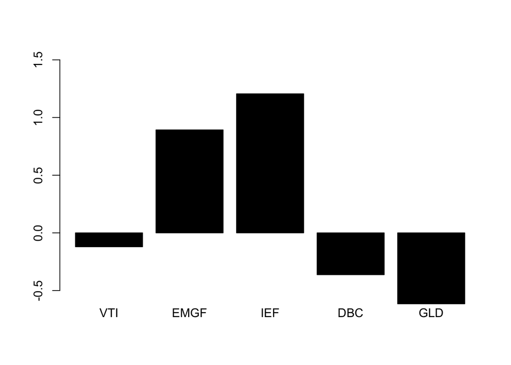

```r
#Mixed estimation of returns

Omega <- diag(diag(Sigma), n, n)
mu_mixed <-
  solve(solve(tau * Sigma) + solve(Omega)) %*% (solve(tau * Sigma) %*% mu +
                                                  solve(Omega) %*% Q)

#Tactical allocation with views directly

A_Q <- t(e) %*% solve(Sigma) %*% Q
omega_Q <- 1 / as.numeric(A_Q) * solve(Sigma) %*% Q
barplot(as.numeric(omega_Q), col = 'black', names.arg = barnames, ylim = c(-0.5,1.5))
```

We can add the following comments on the new portfolio allocation under Black-Litterman approach, including asset views.

Incorporating views into the portfolio has resulted in diverse adjustments across asset classes, reflecting the investor’s evolving outlook on each. These changes are indicative of a dynamic strategy that aims to capitalize on various market scenarios. It’s crucial to consider these allocations within the context of the investor’s overall investment objectives and risk tolerance, as they play a pivotal role in shaping the portfolio’s risk-return profile.

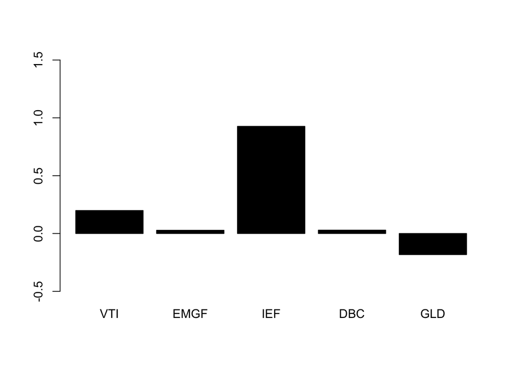

```r
#Tactical allocation with mixed estimation
A_mixed <- t(e) %*% solve(Sigma) %*% mu_mixed
omega_mixed <- 1 / as.numeric(A_mixed) * solve(Sigma) %*% mu_mixed
barplot(as.numeric(omega_mixed), col = 'black', names.arg = barnames, ylim = c(-0.5,1.5))
```